# Auckland University Walk Observation!

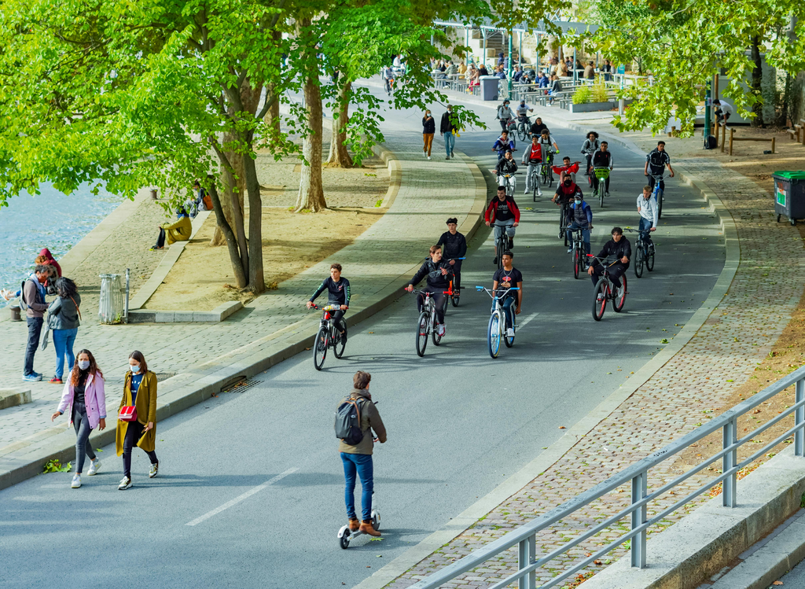

## This is an exploration of people’s movement and actvities during walks around the University of Auckland. It looks at patterns in crowd size, activities, weather conditions, and time of day aross different University of Auckland campuses.

## Runners/joggers Across Different Weather Conditions

This plot shows how different weather conditions can affect the number of runners/joggers.

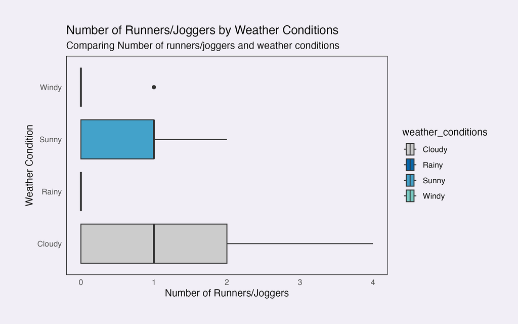

Box plot showing the distribution of runners/joggers across different weather conditions including cloudy, rainy, sunny, and windy weather. Cloudy weather conditions showed the highest number of runners/joggers on average, followed by sunny, windy, and rainy weather.

This is interesting, as I initially expected that there might be more runners and joggers on sunny days, however it seems that cooler and cloudier conditions may be more preferred overall for running and jogging.

## Average Running Activity Across UOA Campuses

This plot compares the average number of runners/joggers observed at City campus and Grafton campus.

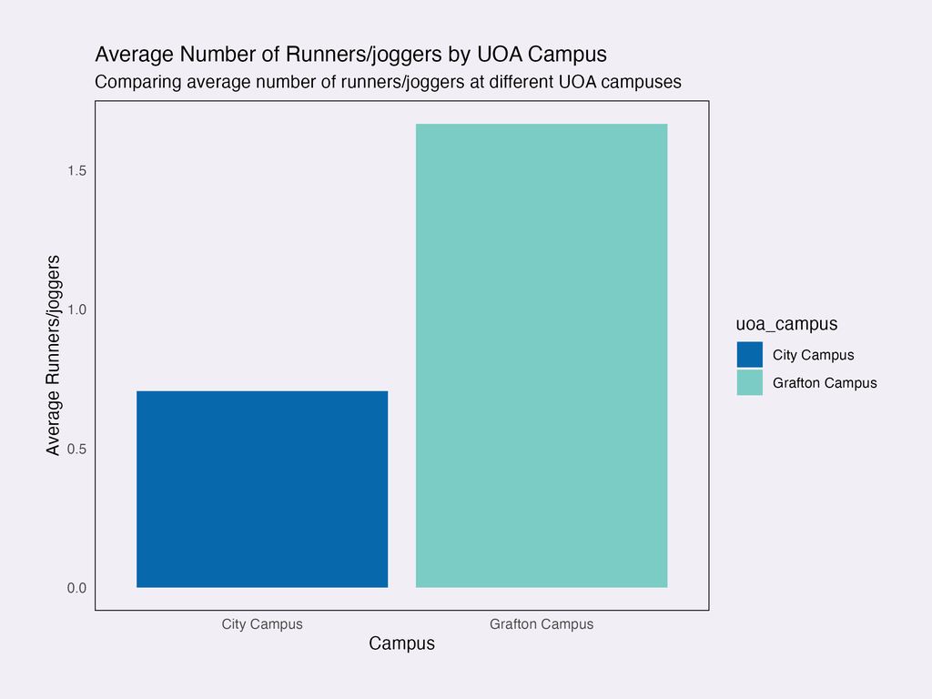

Bar chart comparing average number of runners/joggers between City Campus and Grafton Campus, with Grafton Campus showing a higher average number of runners/joggers.

This was expected because there are more areas suitable for running and jogging around Grafton Campus, such as the Auckland domain, and Grafton bridge is also nearby.

## Activities Observed by Time of Day and Campus

This plot looks at how observed activities vary across different times of the day and between campuses.

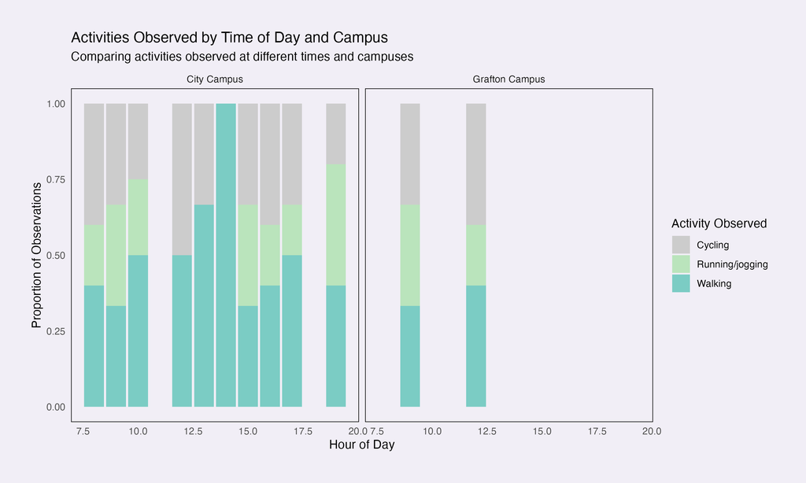

Stacked proportional bar chart showing observed activities of walking, running/jogging, and cycling across hours of the day between City Campus and Grafton Campus. Walking is the most commonly observed activity across most times of the day.

There is lots of walking observed especially around midday, which is expected as many students tend to be on campus during this time. Cycling also appears to be common throughout the day, particularly during the mornings through to around 12pm. Running/jogging seems to be more commonly observed during the mornings and afternoon, compared to the middle of the day.

## Conclusion

Overall, weather conditions, campus location, and time of day all have an effect on the patterns of people’s movement and activity across the University of Auckland campuses.

Walking was the most commonly observed activity, with high numbers of runners/joggers in cloudy weathers, and there tends to be more runners/joggers observed at Grafton Campus on average.